# How much is that Subaru Outback?

- Show All Code
- Hide All Code
- View Source

Author

Daniel Bagley

```r
pacman::p_load(car, tidyverse, latex2exp)



winto_green <- rgb(16, 32, 27, maxColorValue = 100)
beege <- rgb(59, 46, 31, maxColorValue = 100)
reg_red <- rgb(64, 5, 15, maxColorValue = 100)
timber_green <- rgb(5, 29, 5, maxColorValue = 100)
winter <- rgb(90, 90, 86, maxColorValue = 100)
granite <- rgb(16, 16, 17, maxColorValue = 100)

outback <- read_csv("../../data/outback.csv")

bean <- lm(price ~ miles, data = outback)
back_sqrt <- lm(sqrt(price) ~ miles, data = outback)
b <- coef(back_sqrt)

base_plot <- ggplot(outback, aes(y = price, x = miles)) +
  geom_point(color = beege) +
  theme(panel.background = element_rect(fill = winter),
        panel.grid = element_line(color = granite, linetype = "1213"),
        panel.grid.minor = element_blank(),
        text = element_text(face = "italic"),
        legend.position = "bottom") +
  scale_y_continuous(labels = scales::dollar_format()) +
  scale_x_continuous(breaks = c(0, 50000, 100000, 150000, 200000, 250000))
```

**Collapse**

Press **View Analysis** to see where these conclusions came from.

**View Analysis**

## Backgroud

Currently, I own one car and my wife owns one car. The first is a truck, and the second is a small hatchback. We would like to own only one car, but don’t want to lose the usefulness of the truck or the fuel efficiency of the hatchback. One solution to this may be picking a new vehicle that sort of plays both sides; an SUV crossover. What better example of the Crossover than Subaru’s Outback, a vehicle famous for its rugged dependability and long life? This analysis, then, will seek to determine at which price-point and mileage we should purchase our own Subaru Outback to get the best vehicle value. To do this, we will investigate whether there is a significant relationship between Price and Mileage for randomly-selected Subaru Outbacks, and then use that model to predict vehicle price depreciation over time of our own future Outback.

### Model and Hypotheses

For this analysis, we will create a linear model of the relationship between Price and mileage for the Subaru Outback

$$\underbrace{Y_i}_\text{Price} = \overbrace{\beta_0}^\text{y-int} + \overbrace{\beta_1}^\text{slope} \underbrace{X_i}_\text{Mileage} + \epsilon_i \quad \text{where} \ \epsilon_i \sim N(0, \sigma^2)$$

In this case, it is meaningful to consider both the slope (relationship between price and mileage) and the y-intercept (price at zero miles) of our regression model, so we will test both:

#### Slope

The hypotheses for our slope are given by

$$H_0: \beta_1 = 0$$

$$H_a: \beta_1 \neq 0$$

where $\beta_1$ is the slope of the regression line. If it is not zero, there will be a significant relationship between Price and odometer mileage. In other words, we will be able to predict the change in average price of a Subaru Outback per mile it is driven.

### Data collection procedure

To prevent potentially recording the same vehicle twice (due to it being listed multiple places), the data for this analysis was all collected from CarFax, a used car sales website which appears to give complete information on price, mileage, and year of vehicle construction. To compare the same vehicle across the board, I limited results only to the *Subaru Outback 2.5I Premium*, using the following search: [Subaru Outback Listings](https://www.carfax.com/Used-Subaru-Outback_w620)

In this analysis, we ignored model year as a factor because it appeared linearly co-dependent upon mileage as a predictor of price. Instead, we focused only on price and mileage.

## Data Analysis

Having collected the data, it is now time to test our hypotheses. We will begin by visualizing:

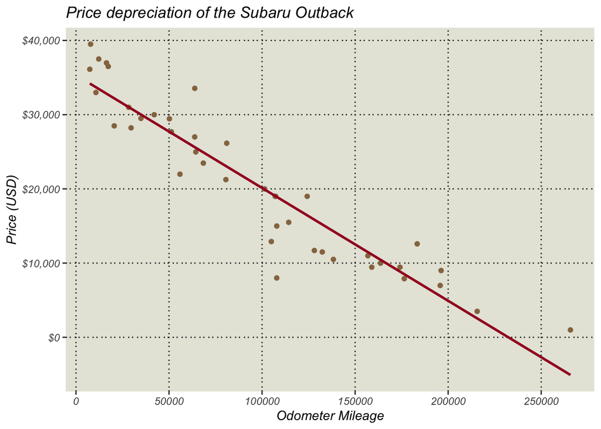

```r
base_plot +
  geom_smooth(method = "lm", se = FALSE,
              formula = "y ~ x", color = reg_red) +
  labs(title = "Price depreciation of the Subaru Outback",
       x = "Odometer Mileage",
       y = "Price (USD)")
```

Notice that the red regression line appears to fit well for most of the data. Because of this, there is a good likelihood that this regression will be a good predictive model for Subaru Outbacks in general.

### Hypothesis test results

Let us examine the results of the test:

```r
pander::pander(summary(bean), caption = "")
```

|  | Estimate | Std. Error | t value | Pr(>\|t\|) |
| --- | --- | --- | --- | --- |
| **(Intercept)** | 35324 | 1025 | 34.45 | 8.2e-31 |
| **miles** | -0.152 | 0.008782 | -17.31 | 6.687e-20 |

| Observations | Residual Std. Error | $R^2$ | Adjusted $R^2$ |
| --- | --- | --- | --- |
| 41 | 3676 | 0.8848 | 0.8819 |

With $R^2 = 0.885$ and significant p-values for both slope and intercept, it seems as though this model is an accurate predictor of Outback Price!

### Diagnostic plots

However, before moving forwards and acting based on these results, it is critical to know whether the data collected is appropriate for linear regression. To determine this, we will examine several plots which demonstrate if the requirements for regression have been met.

First, we check a diagnostic plot of Residuals vs. Fitted values. This will allow us to determine if the two requirements of equal variance and linearity are met. If we see a pattern in the plot, there may be cause to question those requirements. Second, a Normal QQ plot. This plot lets us evaluate whether the data are normally distributed. If the points follow the line without too much deviation, our requirements are met. Lastly, we will examine a plot of the Residuals according to their order. If there is no obvious pattern, we can assume that the requirement of independence is met.

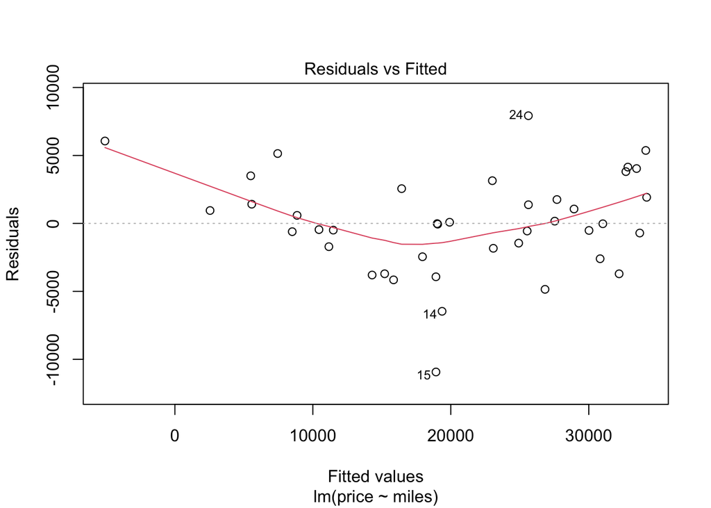

```r
#|label: diagnostic_plots
#|message: false
#|warning: false


plot(bean, which = 1)
```

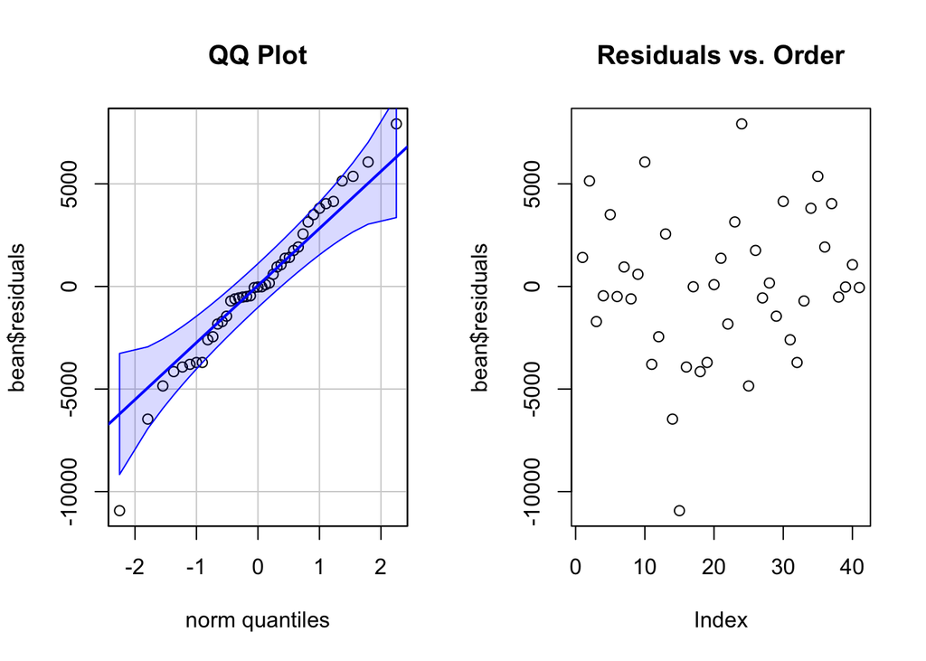

```r
par(mfrow = c(1,2))
qqPlot(bean$residuals, id = FALSE, main = "QQ Plot")
plot(bean$residuals, main = "Residuals vs. Order")
```

```r
par(mfrow = c(1,1))
```

Examining these diagnostic plots leads to several interesting results. First, the QQ plot and Residuals vs. order plots appear normal, with little deviation from the line in the QQ plot and no obvious pattern in the Residuals vs. Order plot. There is, however, one outlier, identified as the 15th item in the data set, which appears to have a much lower price than expected.

Unlike the QQ plot, however, there are some problems with the Residuals vs. fitted plot. As seen by the red line and the general trend of the points, there is a clear curve which indicates our assumption of linearity is not met. Because of this, the data is inappropriate for regression.

### Data Transformation

However, there is a potential solution! If we use a transformation upon our data, it may become linear and therefore meet the regression requirements.

To determine which transformation we should perform, we will examine a Box-Cox plot of log-likelihood. The x-axis of the plot shows the power to which we can raise our response variable for the best possible result:

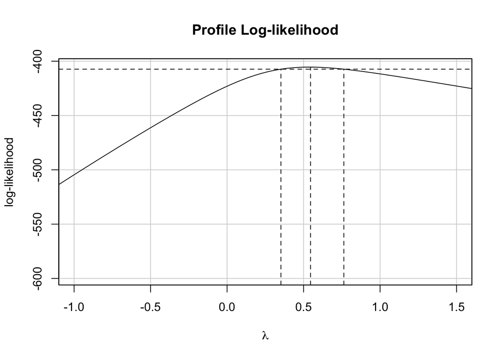

```r
boxCox(bean, xlim = c(-1, 1.5))
```

As the plot reveals, a transformation to the 1/2 power, also known as a square root, will be most effective in addressing the non-linearity of the data. Performing that transformation, we will examine diagnostic plots anew:

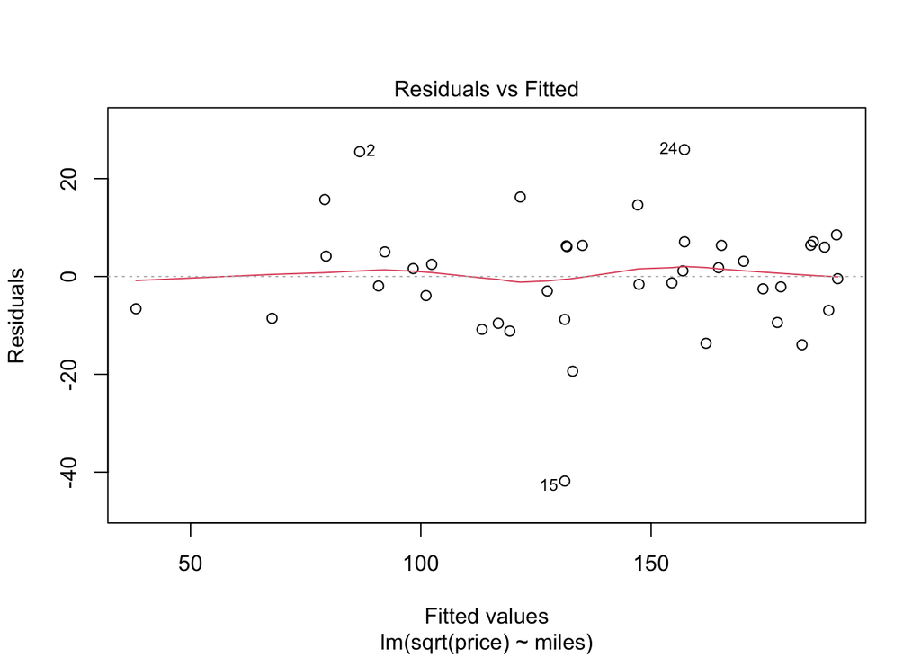

```r
plot(back_sqrt, which = 1)
```

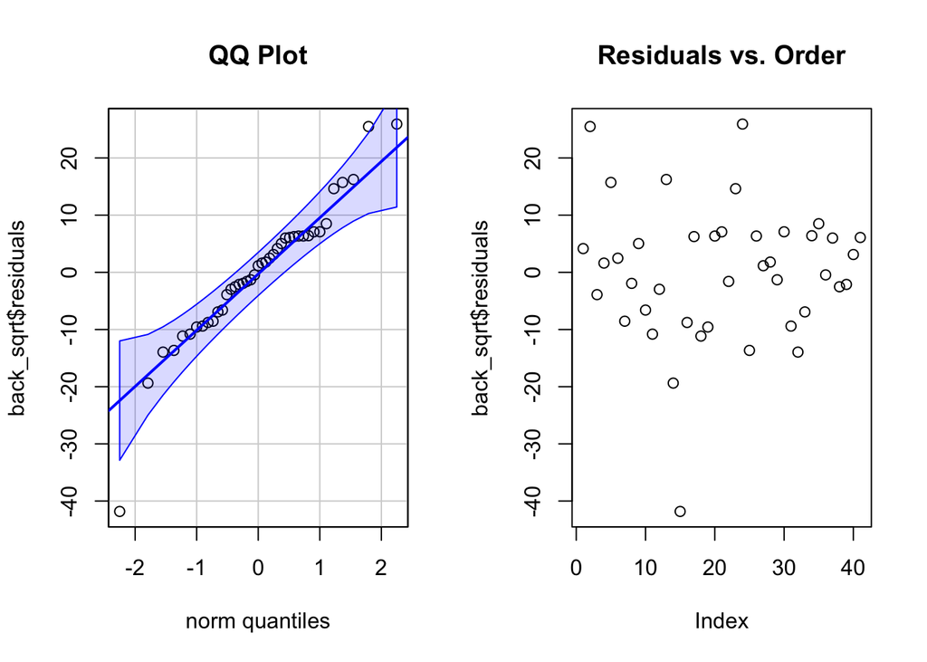

```r
par(mfrow = c(1,2))
qqPlot(back_sqrt$residuals, id = FALSE, main = "QQ Plot")
plot(back_sqrt$residuals, main = "Residuals vs. Order")
```

```r
par(mfrow = c(1,1))
```

The Residuals vs. Fitted plot looks much better and the data now appears linear. The QQ Plot appears to still indicate normality, and the Residuals vs. Order plot has no obvious pattern, though the outlier appears to have become more extreme.

### Model in Prime Space

With more appropriate diagnostic plots, we can proceed with an analysis of the transformed data. Performing the linear regression, we find the following results:

```r
summary(back_sqrt) |> pander::pander(caption = "Transformed model")
```

|  | Estimate | Std. Error | t value | Pr(>\|t\|) |
| --- | --- | --- | --- | --- |
| **(Intercept)** | 194.9 | 3.382 | 57.62 | 2.344e-39 |
| **miles** | -0.0005898 | 2.896e-05 | -20.37 | 2.186e-22 |

Transformed model

| Observations | Residual Std. Error | $R^2$ | Adjusted $R^2$ |
| --- | --- | --- | --- |
| 41 | 12.12 | 0.9141 | 0.9119 |

In our transformed space, we find a model where

$$\hat{Y'}_i = 194.8 - 0.0005902 X_i$$
We can then replace $\hat{Y'}_i$ with $\sqrt{\hat{Y}_i}$ and find

$$\sqrt{\hat{Y}_i} = 194.8 - 0.0005902 X_i$$
which we solve for $\hat{Y}_i$ thusly, returning the model to our original space of interpretation:

$$\hat{Y}_i = (194.8 - 0.0005902 X_i)^2$$

This is powerful because we have now fixed the problems with linearity, fitted a better model, and returned that model to an interpretable space. Note that our $R^2$ is now 0.914 with a Residual Standard Error of 12.12. This RSE is quite good, and the p-values are essentially zero. How does this model compare to the original one?

### Comparing the two models

Visualizing this model compared to the original, we see that the new line has a slight curve (due to now being quadratic) which appears to fit the data better than the straight line, as we expected from the Residuals vs. Fitted plot.

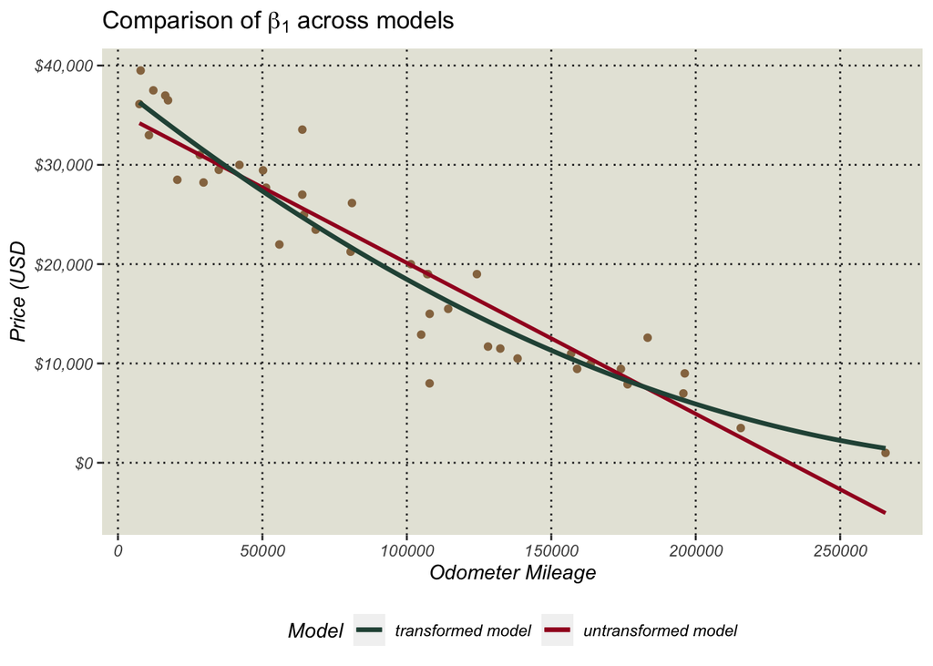

```r
base_plot +
  labs(title = TeX(input = "Comparison of $\\beta_1$ across models"),
       x = "Odometer Mileage",
       y = "Price (USD") +
    geom_smooth(aes(color = "untransformed model"),
              se = FALSE, method = "lm", formula = "y ~ x", alpha = 0.2) +
  stat_function(aes(color = "transformed model"),
                fun = function(x) (b[1] + b[2] * x)^2, size = 1.2) +
  scale_color_manual("Model",values = c(winto_green, reg_red))
```

While the red line fits well for much of the data, it is obvious near the edges that the red line does not account for the changing rate of price depreciation for vehicles with very high or very low mileage. Because of this, the square-root transformed model is a better fit, although it is harder to interpret directly. We therefore use the transformed model to fit the requested plot.

### Constructing a prediction

It seems logical to purchase the vehicle when it will depreciate in price as little as possible. However, waiting too long will result in purchasing an Outback with too many miles and little time. To find a happy medium, we will purchase the vehicle at around 100,000 miles, as it seems most Outbacks last far beyond that but are not as expensive at that mileage. Because both I and my wife like to get as much value as possible from a vehicle, it is likely we will drive a car until it stops working, or at least is near unto that state. Since there are many Outbacks above 200,000 miles but not many past 250,000 miles, that seems like a good estimate of when we will sell/junk the car. We can visualize this interval:

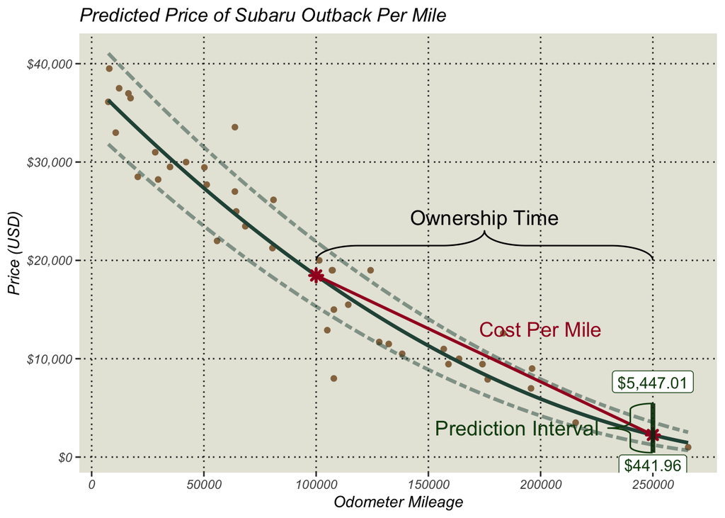

```r
pred_dat <- data.frame(price = predict(back_sqrt,
                                       newdata = data.frame(miles = c(100000, 250000)))^2,
                       miles = c(100000, 250000))

pred_int <- predict(back_sqrt,newdata = data.frame(miles = 250000),
        interval = "prediction")^2

f_plot <- base_plot +
  stat_function(aes(color = "transformed model"),
                fun = function(x) (b[1] + b[2] * x)^2,
                size = 1.2, color = winto_green) +
    stat_function(aes(color = "transformed model"),
                fun = function(x) (b[1] + 12.12 + b[2] * x)^2,
                size = 1.2, color = winto_green, alpha = 0.5, linetype = "3121") +
    stat_function(aes(color = "transformed model"),
                fun = function(x) (b[1] - 12.12 + b[2] * x)^2,
                size = 1.2, color = winto_green, alpha = 0.5, linetype = "3121") +
  geom_point(data = pred_dat, color = reg_red, size = 2, shape = 8, stroke = 1.5) +
  geom_smooth(data = pred_dat, se = FALSE, method = "lm",
              color = reg_red, formula = "y~x") +
  ggbrace::geom_brace(aes(x = c(100000, 250000),
                          y = c(20000, 23000),
                          label = "Ownership Time"),
                      inherit.aes = F, inherit.data = F,
                      labelsize = 5) +
  annotate(geom = "text", x = 200000, y = 13000,
           label = "Cost Per Mile",
           color = reg_red, size = 5) +
  labs(title = "Predicted Price of Subaru Outback Per Mile",
       x = "Odometer Mileage",
       y = "Price (USD)") +
   geom_segment(aes(x = 250000, xend = 250000,
                  y = pred_int[2], yend = pred_int[3]),
               color = timber_green, size = 1.5, alpha = 0.06) +
  annotate("label", label = str_c("$",round(pred_int[2],2)),
           y = pred_int[2], x = 250000, vjust = 1.1, color = timber_green) +
   annotate("label", label = "$5,447.01",
            y = pred_int[3], x = 250000, vjust = -0.5, color = timber_green) +
  ggbrace::geom_brace(aes(x = c(230000, 249900), y = c(pred_int[2], pred_int[3]),
                 label = "Prediction Interval"),
             inherit.aes = FALSE, inherit.data = FALSE,
             rot = 270, labelsize = 5, color = timber_green)


f_plot
```

Over this period, we find that the Purchase Cost per mile is

$$\frac{18,424.09}{150,000} = 0.1228$$
meaning that the vehicle will cost approximately 12.3 cents per mile over that period.

Obviously the cost per mile decreases as the mileage of the vehicle increases. It would therefore be advantageous to purchase the vehicle and then keep it as long as possible, but also to purchase it for as little as possible, which only occurs as the mileage increases.